# Lokaverkefni nafn hér

#### The lasso

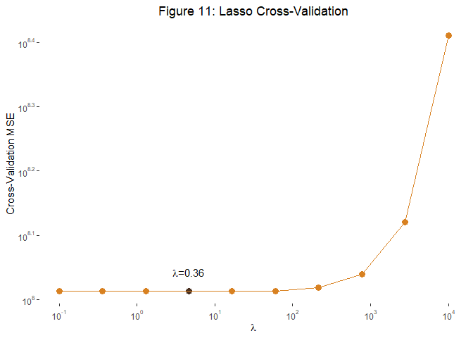

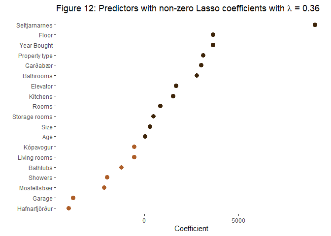

Figure 12 shows the 19 predictors that Lasso deemed influental regarding property worth. The bottom seven variables have a negative relationship with property worth while the remaining have a positive relationship. The variables Seltjarnarnes, number of floors, year the property was bought, Garðabær, Hafnarfjörður and number of garages are the most influential according to the lasso.

The model explained around 76% of property worth variance ($R^2$). With training error around 36.95 m.ISK and test error around 36.84 m.ISK.

The main issue with Lasso are correlated/confounding variables. As seen earlier (see Figure 10) square meters (size of property) came in second when it comes to explaining variance in the data. In figure 12 this variable (size) is included but its coefficient has been reduced almost to zero. Meanwhile, all the variables from the first dimension of the factor analysis appear to also be included here. Lasso is blind to the influence of square meter on property worth (due to high correlation) and it is important to keep that in mind and not exclude the effect that square meter has on property worth.

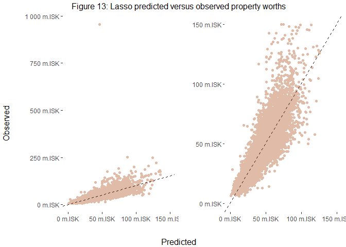

#### Boosting

We ran cross-validation on multiple combinations of trees. Tuning the parameters resulted in a model with 500 boosting iterations (n.trees = 500), a max tree depth of ten (interaction depth = 10), and a $\lambda$ of 0.1. The minimum terminal node size was kept constant at 10.

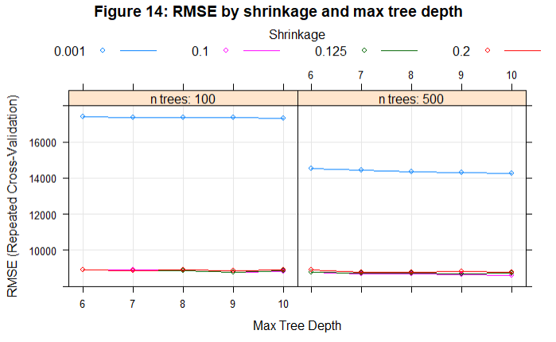

In figure 14 we see a plot of the RMSE via cross-validation according to various measures of tree size and shrinkage value. We can see here that using 500 boosting iterations, with $\lambda$ of 0.1 and a max tree depth of 10 results in the lowest RMSE out of all the tree combinations that were tested.

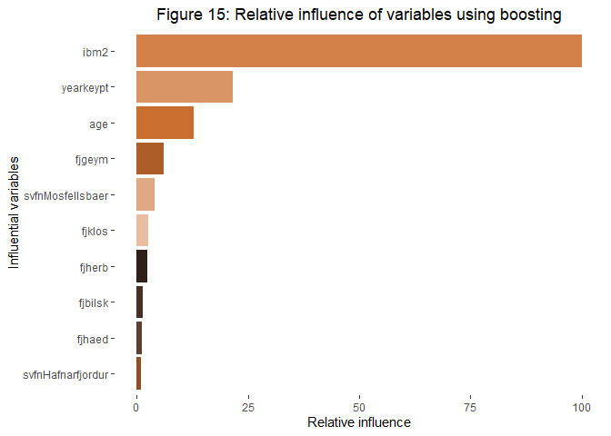

As shown in figure 15, there are three variables that have higher relative importance. They are square meters of property, the year the property was bought and the age of the property. Square meters per property is by far the most important variable. In figures 5 and 8 in the exploratory analysis we learned that the more square meters are in a property the more it is worth and that property worth increases the younger the property is.

Table 1: Comparison of boosting and the lasso

[output not shown]

Table 1: Comparison of boosting and the lasso (log10)

|  | MSE | RMSE | Variables |
| --- | --- | --- | --- |
| Boosting | 7.65 | 0.44 | 10 |
| Lasso | 9.13 | 0.48 | 19 |

## Part III: Predicting property age (old or new)

Here we will predict whether a property is old or new. We’ve created a new binary variable: If the property age exceeds the overall median age (32 years) it is categorised as an old property, and the remaining as new properties.

We will use quadratic discriminant analysis (QDA), logistic regression and random forest to predict whether a property is old or new.

#### Quadratic discriminant analysis

| Table 2: Quadratic discrimnant analysis | Table 2: Quadratic discrimnant analysis True values Old | Table 2: Quadratic discrimnant analysis True values New |
| --- | --- | --- |
| Old | 4584 | 1741 |
| New | 772 | 3438 |

#### Logistic regression

| Table 3: Logistic Regression | Table 3: Logistic Regression True values Old | Table 3: Logistic Regression True values New |
| --- | --- | --- |
| Old | 4490 | 1421 |
| New | 866 | 3758 |

| Table 4: Comparison of QDA and LR | Table 4: Comparison of QDA and LR QDA | Table 4: Comparison of QDA and LR LR |
| --- | --- | --- |
| Accuracy | 76% | 78% |
| True negatives | 44% | 43% |
| False positives | 7% | 8% |
| False negatives | 17% | 13% |
| True positives | 33% | 36% |

In table 4 we see a comparison of the results between QDA and logistic regression. The two methods have very similar results, although the percentage of false negatives is slightly (still noticably) higher for QDA.

## Random Forest

Finding out the optimal mtry value for random forrest

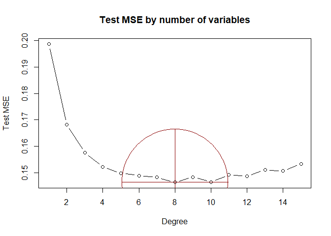

Using random Forest with the optimal mtry variable which is 8.

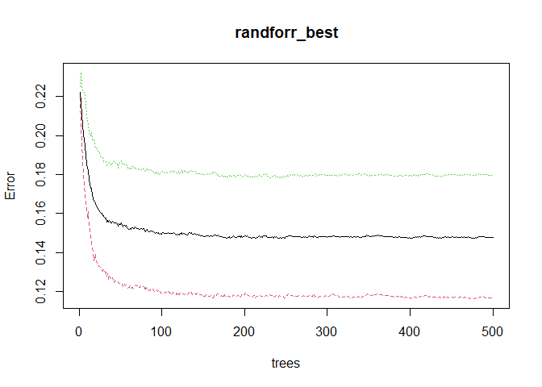

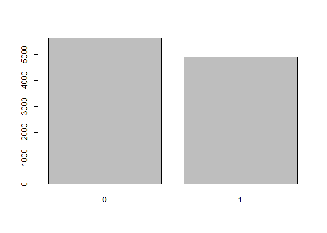

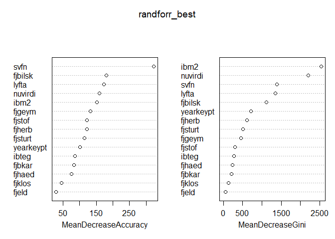